# Part I - PISA Data Exploration

## Introduction

PISA is a survey of students' skills and knowledge as they approach the end of compulsory education. It is not a conventional school test. Rather than examining how well students have learned the school curriculum, it looks at how well prepared they are for life beyond school.

Around 510,000 students in 65 economies took part in the PISA 2012 assessment of reading, mathematics and science representing about 28 million 15-year-olds globally. Of those economies, 44 took part in an assessment of creative problem solving and 18 in an assessment of financial literacy.

## Preliminary Wrangling

```python
# import all packages and set plots to be embedded inline
import numpy as np
import pandas as pd
import matplotlib.pyplot as plt
import seaborn as sns
import zipfile

sns.set_style('darkgrid')
%matplotlib inline
```

After looking at the `pisadict2012.csv` file, which contains information about the columns names of the PISA dataset. We selected some interesting features for investigation.

The `pisa2012.csv` file is 2.6 GiB, so if we attempt to load the entire dataset with all of its columns, Jupyter Notebook will be unable to complete the task.

```python
features = ['PV1MATH', 'PV2MATH', 'PV3MATH', 'PV4MATH', 'PV5MATH',
       'PV1READ', 'PV2READ', 'PV3READ', 'PV4READ', 'PV5READ',
        'PV1SCIE', 'PV2SCIE', 'PV3SCIE', 'PV4SCIE', 'PV5SCIE',
        'WEALTH', 'CNT', 'ST04Q01', 'HISCED',
        'TIMEINT', 'ST11Q01', 'ST11Q02'
       ]
```

Here's a description of each feature:

- **PV1MATH**: Plausible value 1 in mathematics

After unzipping the dataset, let's load it from `pisa2012.csv` by selecting the features above.

```python
%time

import zipfile
with zipfile.ZipFile('pisa2012.csv.zip', 'r') as zip_ref:
    zip_ref.extractall('.')
```

```
CPU times: user 4 µs, sys: 1e+03 ns, total: 5 µs
Wall time: 6.91 µs
```

```python
df = pd.read_csv('pisa2012.csv', sep=",", encoding = "ISO-8859-1", usecols=features)
```

Let's calculate the averages of math, reading, and science scores by creating new columns `math_avg`, `reading_avg` and `science_avg` and dropping the old columns.

```python
df['math_avg'] = df.loc[:, ['PV1MATH', 'PV2MATH', 'PV3MATH', 'PV4MATH', 'PV5MATH']].mean(axis=1)
df['reading_avg'] = df.loc[:, ['PV1READ', 'PV2READ', 'PV3READ', 'PV4READ', 'PV5READ']].mean(axis=1)
df['science_avg'] = df.loc[:, ['PV1SCIE', 'PV2SCIE', 'PV3SCIE', 'PV4SCIE', 'PV5SCIE']].mean(axis=1)

df.drop(columns=['PV1MATH', 'PV2MATH', 'PV3MATH', 'PV4MATH', 'PV5MATH',
                 'PV1READ', 'PV2READ', 'PV3READ', 'PV4READ', 'PV5READ',
                 'PV1SCIE', 'PV2SCIE', 'PV3SCIE', 'PV4SCIE', 'PV5SCIE'], inplace=True)
```

The names of the columns should be renamed to meaningful names.

```python
df.rename({'WEALTH': 'wealth', 'CNT': 'country', 'ST04Q01': 'gender',
          'HISCED': 'parents_education_level', 'TIMEINT': 'computer_use_time',
          'ST11Q01': 'mother_at_home', 'ST11Q02': 'father_at_home'},
          axis='columns', inplace=True)
```

```python
df.head()
```

|  | country | gender | mother_at_home | father_at_home | parents_education_level | computer_use_time | wealth | math_avg | reading_avg | science_avg |
| --- | --- | --- | --- | --- | --- | --- | --- | --- | --- | --- |
| 0 | Albania | Female | Yes | Yes | ISCED 3A, ISCED 4 | NaN | -2.92 | 366.18634 | 261.01424 | 371.91348 |
| 1 | Albania | Female | Yes | Yes | ISCED 5A, 6 | NaN | 0.69 | 470.56396 | 384.68832 | 478.12382 |
| 2 | Albania | Female | Yes | Yes | ISCED 5A, 6 | NaN | -0.23 | 505.53824 | 405.18154 | 486.60946 |
| 3 | Albania | Female | Yes | Yes | ISCED 5A, 6 | NaN | -1.17 | 449.45476 | 477.46376 | 453.97240 |
| 4 | Albania | Female | Yes | Yes | ISCED 3A, ISCED 4 | NaN | -1.17 | 385.50398 | 256.01010 | 367.15778 |

```python
df.shape
```

```
(485490, 10)
```

```python
df.describe()
```

|  | computer_use_time | wealth | math_avg | reading_avg | science_avg |
| --- | --- | --- | --- | --- | --- |
| count | 297074.000000 | 479597.00000 | 485490.000000 | 485490.000000 | 485490.000000 |
| mean | 50.895996 | -0.33701 | 469.651234 | 472.006964 | 475.808094 |
| std | 40.987895 | 1.21530 | 100.786610 | 98.863310 | 97.998470 |
| min | 0.000000 | -6.65000 | 54.767080 | 6.445400 | 25.158540 |
| 25% | 19.000000 | -1.04000 | 396.019620 | 405.044200 | 405.762800 |
| 50% | 39.000000 | -0.30000 | 465.734520 | 475.477980 | 475.512860 |
| 75% | 71.000000 | 0.43000 | 540.123060 | 542.831195 | 546.381920 |
| max | 206.000000 | 3.25000 | 903.107960 | 849.359740 | 857.832900 |

```python
df.info()
```

```
<class 'pandas.core.frame.DataFrame'>
RangeIndex: 485490 entries, 0 to 485489
Data columns (total 10 columns):
 #   Column                   Non-Null Count   Dtype
---  ------                   --------------   -----
 0   country                  485490 non-null  object
 1   gender                   485490 non-null  object
 2   mother_at_home           460559 non-null  object
 3   father_at_home           441036 non-null  object
 4   parents_education_level  473091 non-null  object
 5   computer_use_time        297074 non-null  float64
 6   wealth                   479597 non-null  float64
 7   math_avg                 485490 non-null  float64
 8   reading_avg              485490 non-null  float64
 9   science_avg              485490 non-null  float64
dtypes: float64(5), object(5)
memory usage: 37.0+ MB
```

Let's drop rows with missing values

```python
df.dropna(inplace=True)
```

After dropping rows with missing values, we're left with 268,414 students.

```python
df.shape
```

```
(268414, 10)
```

### What is the structure of your dataset?

There are 485,490 students in the dataset with 635 features but we loaded only 10 features (`country`. `gender`, `mother_at_home`, `father_at_home`, `parents_education_level`, `computer_use_time`, `wealth`, `math_avg`, `reading_avg` and `science_avg`). After cleaning the dataset we're left with 268,414 students.

The variables `country`, `gender`, `mother_at_home`, `father_at_home` and `parents_education_level` are categorical and other variables are numeric.

### What is/are the main feature(s) of interest in your dataset?

We are interested in answering the following questions:

- What are the effects of gender on students' scores on different subjects?
- Which countries have better scores in different subjects?
- Does parental companionship influence student's scores?
- Are there relationships between math score, reading score and science score?

### What features in the dataset do you think will help support your investigation into your feature(s) of interest?

I expect that females will perform better than males in all subjects. Additionally, I expect that Asian students will perform better in math and science subjects.

## Univariate Exploration

Let's create this function that makes count plots, we're going to use it in several explorations later.

```python
def count_plot(df, x_var, hue_var=None, color=0, palette=None, order=None, hue_order=None, figsize=(14, 6), orient='v'):
    # this function plots a count plot

    # figsize must be turned off for subplots
    if figsize:
        plt.figure(figsize=figsize)

    if orient=='v': # vertical orientation
        kwargs = {'x': x_var, 'color': None if color == 'all' else sns.color_palette()[color]}
    elif orient=='h': # horizontal orientation
        kwargs = {'y': x_var, 'color': None if color == 'all' else sns.color_palette()[color]}
    else:
        print('Orient has to be either "h" or "v"')

    # make the plot
    ax = sns.countplot(data=df, hue=hue_var, palette=palette,
                       order=order, hue_order=hue_order,
                       **kwargs)

    # clean up variable names
    x_var = x_var.replace('_', ' ').title()
    if hue_var:
        hue_var = hue_var.replace('_', ' ').title()

    # set title
    plt.title(f'Distribution of {x_var} {"by" if hue_var else ""} {hue_var if hue_var else ""}',
              size=20, weight='bold');
    # dictionnary for the labels keywords
    keys = {f'{"y" if orient=="h" else "x"}label':x_var, f'{"y" if orient=="v" else "x"}label': 'Count'}
    plt.gca().set(**keys)
```

### What is the number of students in each country?

Most of the students who took the survery are from Italy, Mexico and Spain.

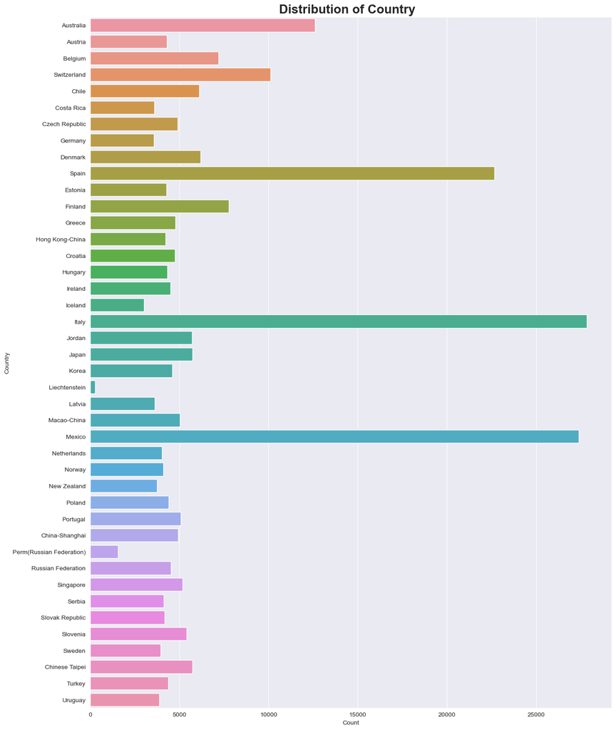

```python
count_plot(df, 'country', orient='h', figsize=(15, 20), color='all')
```

### Boxplot of number of students in each country

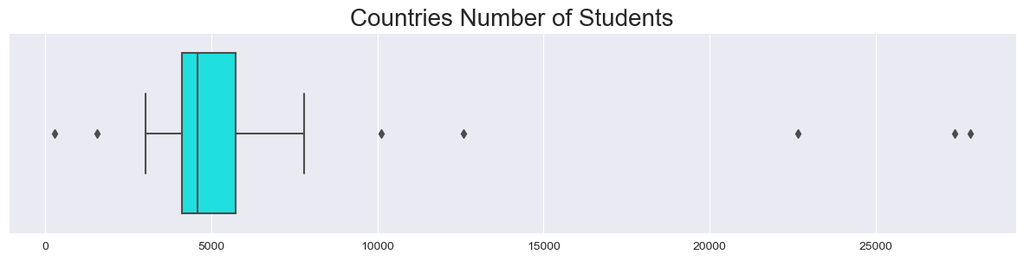

```python
countries_counts = df.country.value_counts()

fig = plt.figure(figsize=(15, 3))
ax = sns.boxplot(countries_counts, x=countries_counts.index, color='cyan')
ax.set(xlabel='', ylabel='')
plt.title('Countries Number of Students', size=20);
```

### Average score distribution for each subject

The distributions for all subjects look like a gaussian distribution.

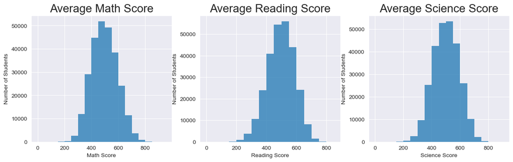

```python
fig = plt.figure(figsize = (15, 4))

binsize = 50

subjects_scores = {'Math Score': 'math_avg', 'Reading Score': 'reading_avg', 'Science Score': 'science_avg'}
for idx, sub in enumerate(subjects_scores):
    bin_edges = np.arange(0, df[subjects_scores[sub]].max()+binsize, binsize)
    ax = fig.add_subplot(1,3,idx+1)
    ax = sns.histplot(df[subjects_scores[sub]], bins = bin_edges, kde=False, linewidth=0);
    ax.set(xlabel=sub, ylabel='Number of Students')
    plt.title(f'Average {sub}', size=20);
```

### Genders percentages

The gender ratios are almost equal.

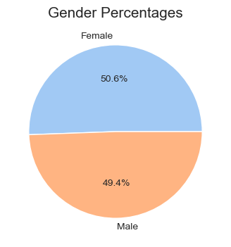

```python
fig = plt.figure(figsize = (6, 4))

ax = df.gender.value_counts().plot.pie(
    autopct='%1.1f%%',
    colors=sns.color_palette('pastel'),
    ylabel=''
);
plt.title('Gender Percentages', size=15);
```

### Wealth distribution

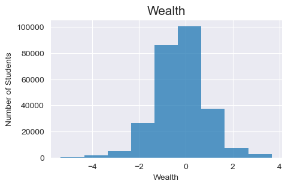

```python
fig = plt.figure(figsize = (5, 3))

binsize = 1

bin_edges = np.arange(df.wealth.min(), df.wealth.max()+binsize, binsize)
ax = sns.histplot(df.wealth, bins = bin_edges, kde=False, linewidth=0);
ax.set(xlabel='Wealth', ylabel='Number of Students')
plt.title('Wealth', size=15);
```

### Time of Computer Use distribution

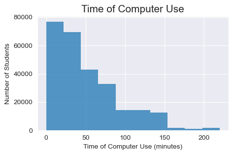

```python
fig = plt.figure(figsize = (5, 3))

binsize = 22

bin_edges = np.arange(0, df.computer_use_time.max()+binsize, binsize)
ax = sns.histplot(df.computer_use_time, bins = bin_edges, kde=False, linewidth=0);
ax.set(xlabel='Time of Computer Use (minutes)', ylabel='Number of Students')
plt.title('Time of Computer Use', size=15);
```

### Mother at Home - Father at Home

Most students' parents are at home.

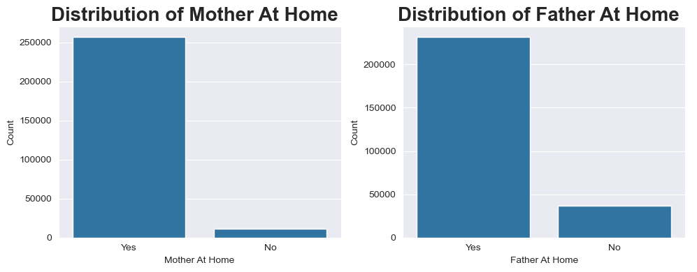

```python
fig = plt.figure(figsize = (10, 4))

ax2 = fig.add_subplot(1,2,1)
count_plot(df, 'mother_at_home', figsize=None)

ax2 = fig.add_subplot(1,2,2)
count_plot(df, 'father_at_home', figsize=None)

plt.tight_layout()
```

### Parents Highest Education Level

Most parents have an education level of ISCED 5A, 6. Few of them (less than 5000) didn't recieve any education.

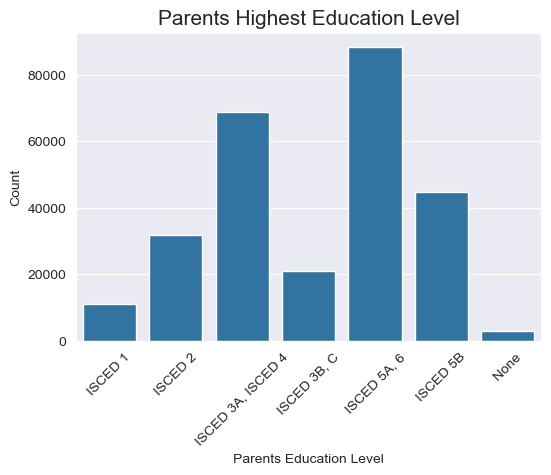

```python
count_plot(df, 'parents_education_level', orient='v', figsize=(6, 4), order=sorted(df.parents_education_level.unique()))
plt.xticks(rotation=45)
plt.title('Parents Highest Education Level', size=15);
```

## Bivariate Exploration

### Students Gender by Country

The majority of countries display a nearly equal gender distribution.

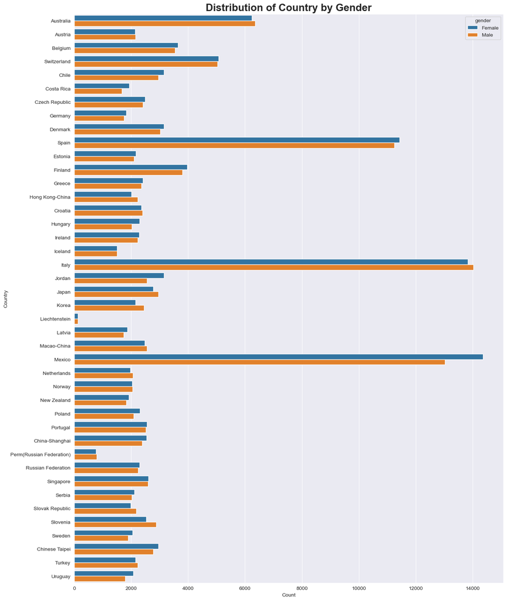

```python
count_plot(df, 'country', hue_var='gender', orient='h', figsize=(15, 20), color='all')
```

### Average Scores Based on Gender

Male students outperform female students in math while female students outperform male students in reading. In terms of average science scores, both genders are almost equal.

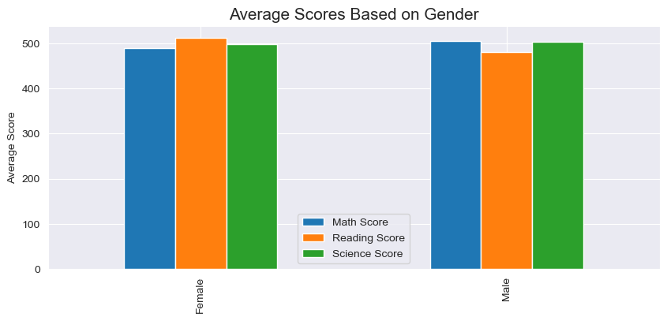

```python
genders_scores = df.groupby(['gender']).mean().loc[:, ['math_avg', 'reading_avg', 'science_avg']]
genders_scores.rename({'math_avg': 'Math Score',
                       'reading_avg': 'Reading Score',
                       'science_avg': 'Science Score'}, inplace=True, axis=1)
ax = genders_scores.plot.bar(figsize=(10, 4));
ax.set(xlabel='', ylabel='Average Score');
plt.title('Average Scores Based on Gender', size=15);
```

### Scores Distrubtion Based on Gender

Males consistently perform better than females in math. But when it comes to reading, it's the opposite.

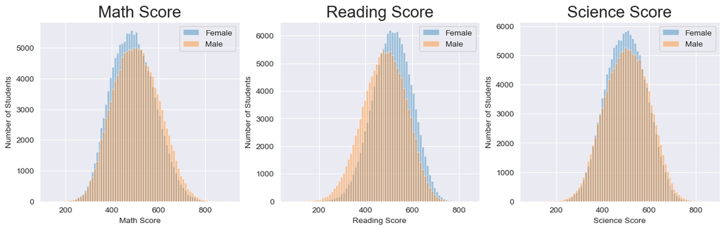

```python
fig = plt.figure(figsize = (15, 4))

binsize = 10

subjects_scores = {'Math Score': 'math_avg', 'Reading Score': 'reading_avg', 'Science Score': 'science_avg'}
for idx, sub in enumerate(subjects_scores):
    bin_edges = np.arange(df[subjects_scores[sub]].min(), df[subjects_scores[sub]].max()+binsize, binsize)
    ax = fig.add_subplot(1,3,idx+1)
    plt.hist(data=df.query('gender == "Female"'), x=subjects_scores[sub], alpha=.4, bins=bin_edges, label='Female')
    plt.hist(data=df.query('gender == "Male"'), x=subjects_scores[sub], alpha=.4, bins=bin_edges, label='Male')
    plt.legend();
    ax.set(xlabel=sub, ylabel='Number of Students')
    plt.title(f'{sub}', size=20);
```

### Relationship Between Average Scores of Math, Reading and Science

From the two figures below, it appears that there is a strong positive correlation between each subject and the other.

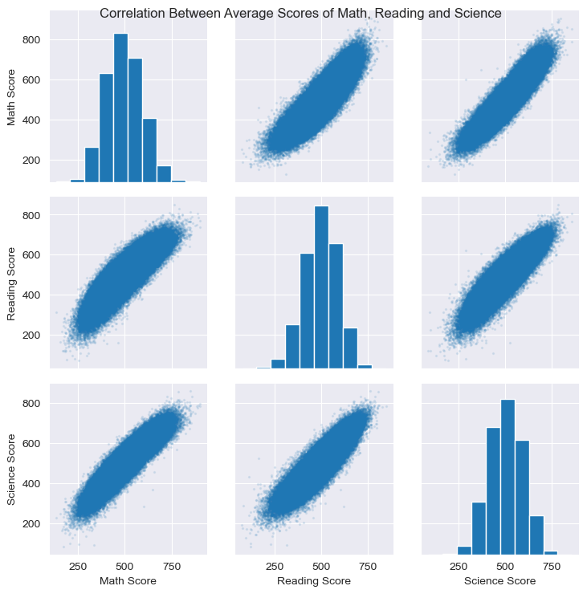

```python
ax = sns.PairGrid(data = df.rename(
    {'math_avg': 'Math Score', 'reading_avg': 'Reading Score', 'science_avg': 'Science Score'},
    axis=1),
    vars = ['Math Score', 'Reading Score', 'Science Score']);
ax.map_diag(plt.hist);
ax.map_offdiag(plt.scatter, s=2, alpha=0.1);
ax.fig.suptitle("Correlation Between Average Scores of Math, Reading and Science");
```

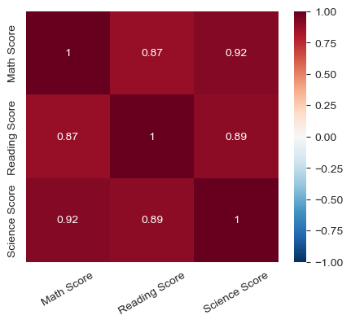

```python
fig = plt.figure(figsize = (5, 4))

temp = df.loc[:, ['math_avg', 'reading_avg', 'science_avg']]
temp.rename(
    {'math_avg': 'Math Score', 'reading_avg': 'Reading Score', 'science_avg': 'Science Score'},
    inplace=True, axis=1
)
sns.heatmap(data=temp.corr(),
            cmap="RdBu_r",annot=True, vmin=-1, vmax=1);
plt.xticks(rotation=30);
```

## Multivariate Exploration

### Parental Companionship in Math, Reading and Science

Let us first calculate the number of parents at home for each student and then do the following transformation:

0 = None

1 = One

2 = Both

```python
df['father_at_home'] = df['father_at_home'].replace({'Yes': 1, 'No': 0})
df['mother_at_home'] = df['mother_at_home'].replace({'Yes': 1, 'No': 0})

df['parents_at_home'] = df['father_at_home'] + df['mother_at_home']
df['parents_at_home'] = df['parents_at_home'].replace({0: 'None', 1: 'One', 2: 'Both'})
```

The figure below is solid evidence for this; if at least one parent is home, the child scores higher than a child whose parents are not home.

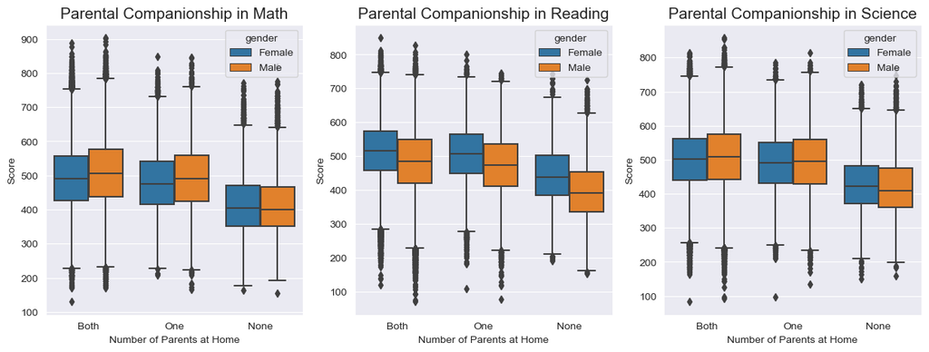

```python
plt.figure(figsize = (15, 5))

ax1 = plt.subplot(1, 3, 1)
ax1 = sns.boxplot(data=df, x='parents_at_home', y='math_avg', hue='gender');
ax1.set(xlabel='Number of Parents at Home', ylabel='Score')
plt.title('Parental Companionship in Math', size=15);

ax2 = plt.subplot(1, 3, 2)
ax2 = sns.boxplot(data=df, x='parents_at_home', y='reading_avg', hue='gender');
ax2.set(xlabel='Number of Parents at Home', ylabel='Score')
plt.title('Parental Companionship in Reading', size=15);

ax3 = plt.subplot(1, 3, 3)
ax3 = sns.boxplot(data=df, x='parents_at_home', y='science_avg', hue='gender');
ax3.set(xlabel='Number of Parents at Home', ylabel='Score')
plt.title('Parental Companionship in Science', size=15);
```

### Average Score in Different Countries for Each Subject

Here, we can see how different scores are distributed among the various countries.

```python
# put subjects  and their scores in columns
data = df[['gender', 'math_avg', 'reading_avg', 'science_avg', 'country']].melt(id_vars=['gender', 'country'],
                                                                               var_name='Subject',
                                                                               value_name='Scores')
# rename subjects
data['Subject'] = data['Subject'].map({'math_avg': 'Math', 'reading_avg': 'Reading', 'science_avg': 'Science'})
```

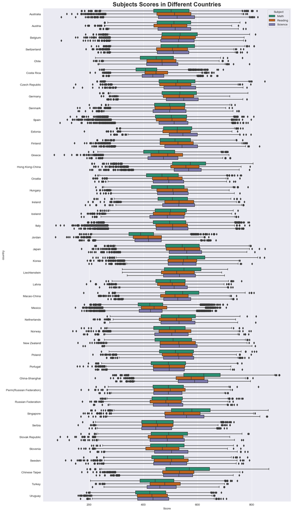

```python
fig = plt.figure(figsize=(15, 30));
ax = sns.boxplot(data=data, x='Scores', y='country', hue='Subject', palette='Dark2');
ax.set(xlabel='Score')
plt.title('Subjects Scores in Different Countries', weight='bold', size=20);
```

### Scores in Different Countries by Gender

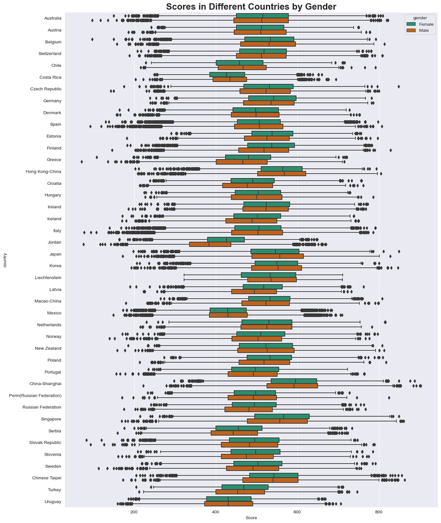

```python
fig = plt.figure(figsize=(15, 20));
ax = sns.boxplot(data=data, x='Scores', y='country', hue='gender', palette='Dark2');
ax.set(xlabel='Score')
plt.title('Scores in Different Countries by Gender', weight='bold', size=20);
```